# RSY-MC2

Patrick, Ben

# Settings

```r
library(tidyverse)
library(recommenderlab)
```

# 1. Erzeugung von Film- & Nutzerprofilen

## 1.1 MovieLense Daten einlesen

```r
data(MovieLense)
```

## 1.2 Binäre User-Liked-Items Matrix für alle Nutzer erzeugen.

```r
#as(MovieLense[1:4, 1:4], "matrix")

user_liked_items_binaer <- binarize(MovieLense, minRating = 4)

user_liked_items_binaer <- as(user_liked_items_binaer, "matrix")

user_liked_items_binaer[1:4, 1:4]
```

```
  Toy Story (1995) GoldenEye (1995) Four Rooms (1995) Get Shorty (1995)
1             TRUE            FALSE              TRUE             FALSE
2             TRUE            FALSE             FALSE             FALSE
3            FALSE            FALSE             FALSE             FALSE
4            FALSE            FALSE             FALSE             FALSE
```

## 1.3 Dimension der User-Liked-Items Matrix prüfen und ausgeben.

```r
dim(user_liked_items_binaer)
```

```
[1]  943 1664
```

Die User-Liked-Items Matrix hat eine Dimension von 943 User und 1664 Items (Movies).

## 1.4 Movie-Genre Matrix für alle Filme erzeugen.

```r
Movie_Genre_df <- MovieLenseMeta %>% select(-c(year, url))

rownames(Movie_Genre_df) <- Movie_Genre_df[,1]
Movie_Genre_df <- Movie_Genre_df %>% select(-c(title))

#Movie_Genre_df

Movie_Genre_matrix <- as.matrix(Movie_Genre_df)

Movie_Genre_matrix[1:5,1:5]
```

```
                  unknown Action Adventure Animation Children's
Toy Story (1995)        0      0         0         1          1
GoldenEye (1995)        0      1         1         0          0
Four Rooms (1995)       0      0         0         0          0
Get Shorty (1995)       0      1         0         0          0
Copycat (1995)          0      0         0         0          0
```

Hier sehen wir ie ersten 5 Items und deren ersten 5 Genre. Werte die 1 annehmen bedeutet, dass das Item dieses Genre aufweist. Werte die 0 aufweisen umgekehrt. Ein Item, bzw Movie kann mehrere Genre aufweisen.

## 1.5 Dimension der Movie-Genre Matrix prüfen und ausgeben.

```r
dim(Movie_Genre_matrix)
```

```
[1] 1664   19
```

Die Movie_genre_matrix hat eine Dimension von 1664 Items und 19 Genre.

## 1.6 Anzahl unterschiedlicher Filmprofile bestimmen und visualisieren.

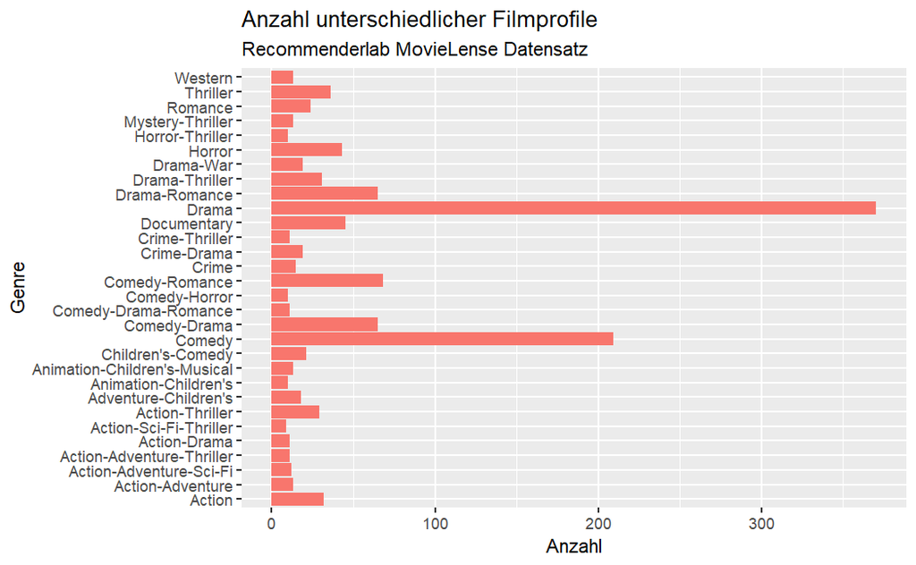

```r
# copy df
Movie_genre_matrix_renamed <- Movie_Genre_matrix

# get all genre cols
colnames <- colnames(Movie_Genre_matrix)

# iterate through genre cols and set 1 to genre col and rest to NA
for (colname in colnames) {
  Movie_genre_matrix_renamed[, colname] <- ifelse(Movie_Genre_matrix[, colname] == 1, colname, NA)
}

#Movie_genre_matrix_renamed[1:4, 1:5]

# create a dataframe
Movie_genre_renamed_df <- as.data.frame(Movie_genre_matrix_renamed)

#Movie_genre_renamed_df

# concat rowwise
Movie_genre_concat_df <- Movie_genre_renamed_df %>% unite("profile", sep = "-", na.rm = TRUE, remove = TRUE)

#Movie_genre_concat_df

Movie_genre_concat_df %>% group_by(profile) %>% summarise(Anzahl = n()) %>% arrange(desc(Anzahl)) %>% head(30) %>% arrange(Anzahl) %>%
ggplot(aes(x = Anzahl, y = profile, fill = "red")) +
  geom_bar(stat = "identity") +
  labs(title = "Anzahl unterschiedlicher Filmprofile",
       x = "Anzahl",
       y = "Genre",
       subtitle = "Recommenderlab MovieLense Datensatz") +
  theme(legend.position="none")
```

Im plot erkennen wir, das Filme mit dem Genre Drama sehr häufig vertreten sind in unserem Datensatz. Als Zweithäufigstes kommt Comedy. Kombinierte Genre die in etwa gleich viel vorkommen sind: Drama-Romance, Comedy-Romance, Comedy-Drama.

## 1.7 Nutzerprofile im Genre-Vektorraum erzeugen.

```r
# get dimension from user genre matrix
#dim(user_liked_items_binaer)
#dim(Movie_Genre_matrix)

user_genre_matrix <- user_liked_items_binaer %*% Movie_Genre_matrix

#user_genre_matrix[1:5, 1:5]

user_genre_profile_df <- as.data.frame(user_genre_matrix)

head(user_genre_profile_df, n=5)
```

|  | unknown | Action | Adventure | Animation | Children's | Comedy | Crime | Documentary | Drama | Fantasy | Film-Noir | Horror | Musical | Mystery | Romance | Sci-Fi | Thriller | War | Western |
| --- | --- | --- | --- | --- | --- | --- | --- | --- | --- | --- | --- | --- | --- | --- | --- | --- | --- | --- | --- |
| 1 | 1 | 39 | 17 | 5 | 5 | 49 | 15 | 5 | 77 | 1 | 1 | 7 | 6 | 3 | 29 | 32 | 30 | 15 | 3 |
| 2 | 0 | 7 | 3 | 1 | 2 | 12 | 6 | 0 | 22 | 0 | 2 | 0 | 0 | 1 | 13 | 2 | 6 | 2 | 0 |
| 3 | 0 | 3 | 2 | 0 | 0 | 3 | 3 | 1 | 7 | 0 | 0 | 0 | 0 | 4 | 2 | 2 | 4 | 2 | 0 |
| 4 | 0 | 5 | 2 | 0 | 0 | 4 | 4 | 1 | 4 | 0 | 0 | 1 | 1 | 3 | 2 | 4 | 7 | 2 | 0 |
| 5 | 1 | 23 | 14 | 8 | 5 | 33 | 7 | 0 | 7 | 1 | 1 | 8 | 4 | 1 | 6 | 19 | 5 | 7 | 1 |

Hier werden die ersten 5 User ausgegeben und deren Nutzerprofile von jedem Genre durch die Multiplikation der user_like_items_binaer und Movie_Genre_Matrix.

## 1.8 Dimension der User-Genre-Profil Matrix prüfen und ausgeben.

```r
dim(user_genre_matrix)
```

```
[1] 943  19
```

Wie zu erwarten haben wir weiterhin 943 User und 19 Genre.

## 1.9 Anzahl unterschiedlicher Nutzerprofile bestimmen, wenn Stärke der

Genre-Kombination (a) vollständig (b) binär berücksichtigt wird.

### 1.9.1 Genre-Kombination vollständig (a)

```r
#head(user_genre_profile_df, n = 5)

# Anzahl unterschiedlicher Nutzerprofile
n_unterschiedliche_profile <- sum(!duplicated(user_genre_profile_df))
paste("Genre-Kombination vollständig betrachtet, Anzahl unterschiedliche Nutzerprofile:", n_unterschiedliche_profile)
```

```
[1] "Genre-Kombination vollständig betrachtet, Anzahl unterschiedliche Nutzerprofile: 943"
```

```r
# Anzahl gleiche Nutzerprofile
paste("Genre-Kombination vollständig betrachtet, Anzahl gleiche Nutzerprofile:",
      nrow(user_genre_profile_df) - n_unterschiedliche_profile)
```

```
[1] "Genre-Kombination vollständig betrachtet, Anzahl gleiche Nutzerprofile: 0"
```

Wir erkennen, dass bei der vollständiger Betrachtung der user_genre_matrix, dass wir 943 unterschiedliche Nutzerprofile aufweisen. Da die Dimension der user_genre_matrix 943 x 19 ist, ist somit jeder user unterschiedlich voneinander.

### 1.9.2 Genre-Kombination binär berücksichtigt (b)

```r
# create binaery dataframe
user_genre_rr_matrix <- as(user_genre_matrix, "realRatingMatrix")

user_genre_binaer_matrix <- as(binarize(user_genre_rr_matrix, minRating = 1), "matrix") * 1

# create binaery dataframe
user_genre_binaer_df <- as.data.frame(user_genre_binaer_matrix)

# Anzahl unterschiedlicher Nutzerprofile
n_unterschiedliche_profile <- sum(!duplicated(user_genre_binaer_df))
paste("Genre-Kombination vollständig betrachtet, Anzahl unterschiedliche Nutzerprofile:", n_unterschiedliche_profile)
```

```
[1] "Genre-Kombination vollständig betrachtet, Anzahl unterschiedliche Nutzerprofile: 381"
```

```r
# Anzahl gleiche Nutzerprofile
paste("Genre-Kombination vollständig betrachtet, Anzahl gleiche Nutzerprofile:",
      nrow(user_genre_binaer_df) - n_unterschiedliche_profile)
```

```
[1] "Genre-Kombination vollständig betrachtet, Anzahl gleiche Nutzerprofile: 562"
```

Betrachten wir unser User Genre Profil nun binär, so erhalten wir 381 unterschiedliche und 562 gleiche Nutzerprofile.

# 2. Ähnlichkeit von Nutzern und Filmen

## 2.1 Cosinus-Ähnlichkeit zwischen User-Genre- und Movie-Genre-Matrix berechnen.

```r
# Testing before Function implementation

head(user_genre_profile_df, n = 3)
```

|  | unknown | Action | Adventure | Animation | Children's | Comedy | Crime | Documentary | Drama | Fantasy | Film-Noir | Horror | Musical | Mystery | Romance | Sci-Fi | Thriller | War | Western |
| --- | --- | --- | --- | --- | --- | --- | --- | --- | --- | --- | --- | --- | --- | --- | --- | --- | --- | --- | --- |
| 1 | 1 | 39 | 17 | 5 | 5 | 49 | 15 | 5 | 77 | 1 | 1 | 7 | 6 | 3 | 29 | 32 | 30 | 15 | 3 |
| 2 | 0 | 7 | 3 | 1 | 2 | 12 | 6 | 0 | 22 | 0 | 2 | 0 | 0 | 1 | 13 | 2 | 6 | 2 | 0 |
| 3 | 0 | 3 | 2 | 0 | 0 | 3 | 3 | 1 | 7 | 0 | 0 | 0 | 0 | 4 | 2 | 2 | 4 | 2 | 0 |

```r
# in Movie_Genre_df
movie_genre_df <- Movie_Genre_df

head(movie_genre_df, n = 3)
```

|  | unknown | Action | Adventure | Animation | Children's | Comedy | Crime | Documentary | Drama | Fantasy | Film-Noir | Horror | Musical | Mystery | Romance | Sci-Fi | Thriller | War | Western |
| --- | --- | --- | --- | --- | --- | --- | --- | --- | --- | --- | --- | --- | --- | --- | --- | --- | --- | --- | --- |
| Toy Story (1995) | 0 | 0 | 0 | 1 | 1 | 1 | 0 | 0 | 0 | 0 | 0 | 0 | 0 | 0 | 0 | 0 | 0 | 0 | 0 |
| GoldenEye (1995) | 0 | 1 | 1 | 0 | 0 | 0 | 0 | 0 | 0 | 0 | 0 | 0 | 0 | 0 | 0 | 0 | 1 | 0 | 0 |
| Four Rooms (1995) | 0 | 0 | 0 | 0 | 0 | 0 | 0 | 0 | 0 | 0 | 0 | 0 | 0 | 0 | 0 | 0 | 1 | 0 | 0 |

```r
# turn both dataframe into a r matrix
user_genre_matrix <- as.matrix(user_genre_profile_df)
movie_genre_matrix <- as.matrix(movie_genre_df)

# create small testing matrices
test_user_genre_matrix <- user_genre_matrix[1:5, 1:5]
test_user_genre_matrix
```

```
  unknown Action Adventure Animation Children's
1       1     39        17         5          5
2       0      7         3         1          2
3       0      3         2         0          0
4       0      5         2         0          0
5       1     23        14         8          5
```

```r
test_movie_genre_matrix <- movie_genre_matrix[1:5, 1:5]
test_movie_genre_matrix
```

```
                  unknown Action Adventure Animation Children's
Toy Story (1995)        0      0         0         1          1
GoldenEye (1995)        0      1         1         0          0
Four Rooms (1995)       0      0         0         0          0
Get Shorty (1995)       0      1         0         0          0
Copycat (1995)          0      0         0         0          0
```

```r
# Calculation testing

z_test = test_user_genre_matrix %*% t(test_movie_genre_matrix)
#z_test

user_genre_rowsums <- sqrt(rowSums(test_user_genre_matrix**2))
movie_genre_rowsums <- sqrt(rowSums(test_movie_genre_matrix**2))

#user_genre_rowsums
#movie_genre_rowsums

n_test = user_genre_rowsums %*% t(movie_genre_rowsums)
#n_test

z_test / n_test
```

```
  Toy Story (1995) GoldenEye (1995) Four Rooms (1995) Get Shorty (1995) Copycat (1995)
1        0.1639124        0.9179095               NaN         0.9040479            NaN
2        0.2672612        0.8908708               NaN         0.8819171            NaN
3        0.0000000        0.9805807               NaN         0.8320503            NaN
4        0.0000000        0.9191450               NaN         0.9284767            NaN
5        0.3219953        0.9164482               NaN         0.8056549            NaN
```

```r
# Function implementation

cosine_sim_func <- function(user_genre_matrix, movie_genre_matrix){
  # matrix multiplication of user_genre_matrix @ movie_genre_matrix.T
  # User Movie Matrix: A x B.T
  zaehler = user_genre_matrix %*% t(movie_genre_matrix)

  # calculating the sqrt(sum(x^2, row matrix)) of each matrix and get a vector
  user_genre_sqrt_rowsum_x2 <- sqrt(rowSums(user_genre_matrix ** 2))
  movie_genre_sqrt_rowsum_x2 <- sqrt(rowSums(movie_genre_matrix ** 2))

  # now we create a matrix out of those two vectors
  # User Movie Matrix: ||A|| x ||B||.T
  nenner = user_genre_sqrt_rowsum_x2 %*% t(movie_genre_sqrt_rowsum_x2)

  # calculate Cosine similarity
  user_movie_cosine_sim_matrix = zaehler / nenner

  user_movie_cosine_sim_matrix
}

# Testing with testdata
cosine_sim_func(test_user_genre_matrix, test_movie_genre_matrix)
```

```
  Toy Story (1995) GoldenEye (1995) Four Rooms (1995) Get Shorty (1995) Copycat (1995)
1        0.1639124        0.9179095               NaN         0.9040479            NaN
2        0.2672612        0.8908708               NaN         0.8819171            NaN
3        0.0000000        0.9805807               NaN         0.8320503            NaN
4        0.0000000        0.9191450               NaN         0.9284767            NaN
5        0.3219953        0.9164482               NaN         0.8056549            NaN
```

```r
# Full dataset
cosine_sim_matrix <- cosine_sim_func(user_genre_matrix, movie_genre_matrix)

#View(cosine_sim_matrix)
```

Bevor die cosine_sim_func(A, B) geschrieben wurde, wurde ein kleines testing Beispiel gemacht und berechnet. Anschliessend wurde die Funktion implementiert und getestet.

## 2.2 Dimension der Matrix der Cosinus-Ähnlichkeiten von Nutzern und Filmen prüfen und ausgeben.

```r
dim(cosine_sim_matrix)
```

```
[1]  943 1664
```

Wir haben 943 User und 1664 Movies in unserer cosine_sim_matrix. Dies entspricht die Anzahl an User und Item, die wir in unserem Datensatz haben. Die Dimensionen der cosine_sim_matrix stimmt somit.

## 2.3 5-Zahlen Statistik für Matrix der Cosinus-Ähnlichkeiten prüfen und ausgeben.

```r
cosine_sim_vector <- as.vector(cosine_sim_matrix)
summary(cosine_sim_vector)
```

```
   Min. 1st Qu.  Median    Mean 3rd Qu.    Max.    NA's
 0.0000  0.2300  0.4070  0.4098  0.5919  0.9768    1664
```

Bei der Cosine Similiarty erhalten wir Werte zwischen 0 und 1. Der Summary gibt uns nur Werte dazwischen aus. Ein Minimum von 0 bedeutet, dass es zwischen User und Film keine ähnlichkeit vorhanden ist. Ein Hoher Wert deutet darauf hin, das User und Film eine hohe ähnlichkeit aufweisen. in der Cosine-Similarity gibt es Gesamthaft 1664 NAs, dies könnte ein User sein, der keinen Film Bewertet hat und somit man keine Cosine-Similarity für diesen User berechnen kann. Vermutung aufgrund der Dimension der cosine_sim_matrix. Um Die Vermutung zu bestätigen müsste man nach einer Zeile (User) suchen, der nur Na Werte aufweist.

## 2.4 Cosinus-Ähnlichkeiten von Nutzern und Filmen mit Dichteplot visualisieren.

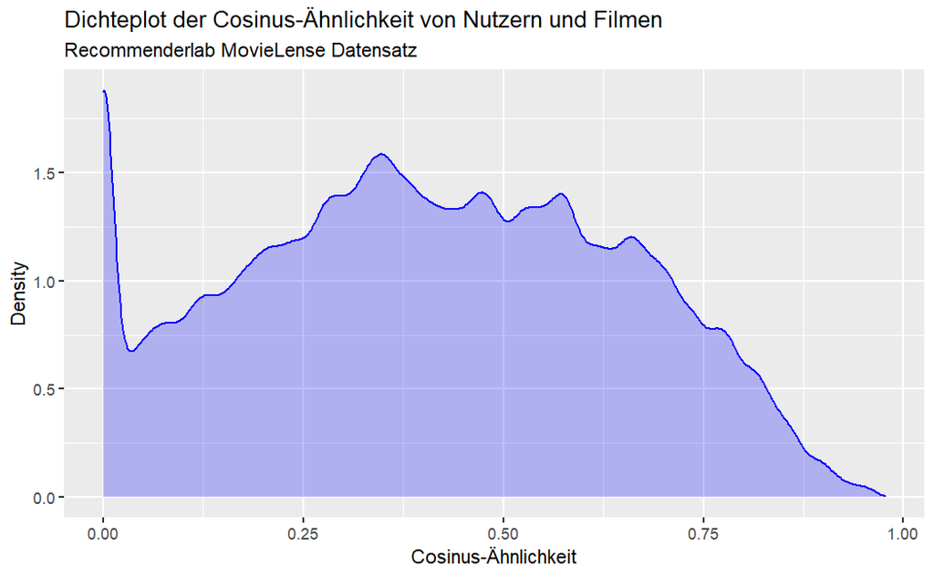

```r
cosine_sim_matrix_df <- as.data.frame(cosine_sim_matrix)

cosine_sim_matrix_df %>%
  pivot_longer(c(colnames(cosine_sim_matrix_df))) %>%
  ggplot(aes(value)) +
  geom_density(color = "blue", fill = "blue", alpha = 0.25) +
  labs(title = "Dichteplot der Cosinus-Ähnlichkeit von Nutzern und Filmen",
       x = "Cosinus-Ähnlichkeit",
       y = "Density",
       subtitle = "Recommenderlab MovieLense Datensatz")
```

Wir erkennen im Dichteplot, das es viele Werte gibt die im Bereich von 0 liegen und es ebenfalls viele Werte hat die 0 sind. Wenige Werte bei denen die Cosisnus-Ähnlichkeit höher 0.8 ist. Es gibt keinen Cosinus-Ähnlichkeits Wert der 1 ist.

## 2.5 Cosinus-Ähnlichkeiten von Nutzern und Filmen mit Dichteplot für Nutzer “241”, “414”, “477”, “526”, “640” und “710” visualisieren.

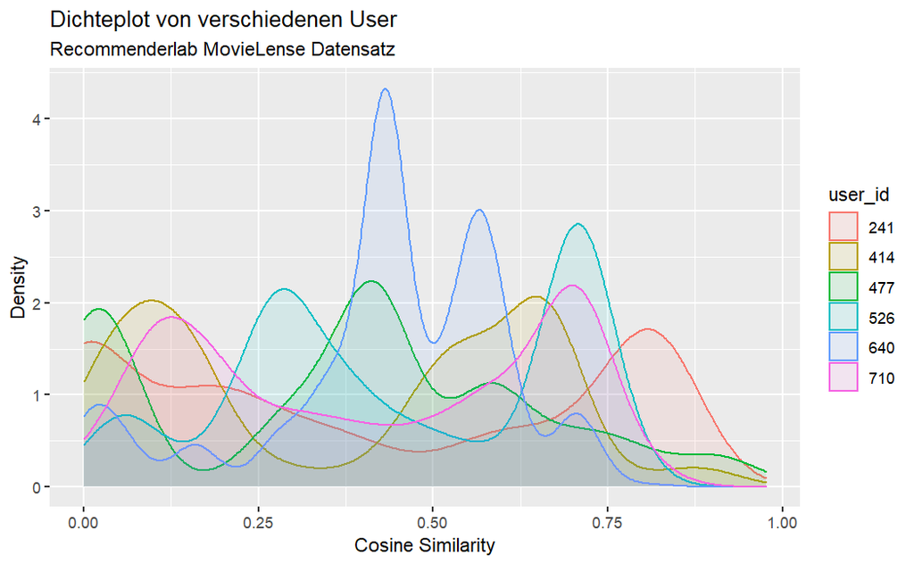

```r
cosine_sim_matrix_user <- cosine_sim_matrix[c(241, 414, 477, 526, 640, 710),]

df_cosine_sim_matrix <- as.data.frame(cosine_sim_matrix_user)

#df_cosine_sim_matrix

df_cosine_sim_matrix <- df_cosine_sim_matrix %>%
  rownames_to_column("user_id")

df_cosine_sim_matrix_long <- df_cosine_sim_matrix %>%
  gather(genre, cosine_sim, -user_id)

#df_cosine_sim_matrix_long

ggplot(df_cosine_sim_matrix_long, aes(x = cosine_sim, fill = user_id, color = user_id)) +
  geom_density(alpha = 0.1) +
  labs(title = "Dichteplot von verschiedenen User",
       x = "Cosine Similarity",
       y = "Density",
       subtitle = "Recommenderlab MovieLense Datensatz")
```

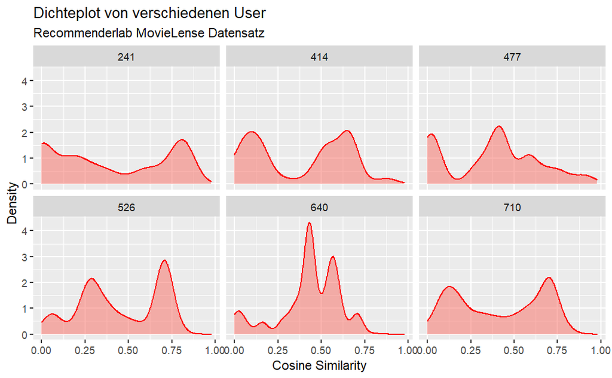

```r
ggplot(df_cosine_sim_matrix_long, aes(x = cosine_sim, fill = "red", alpha = 0.5)) +
  geom_density(color = "red") +
  guides(alpha = "none", fill = "none") +
  facet_wrap(~ user_id) +
  labs(title = "Dichteplot von verschiedenen User",
       x = "Cosine Similarity",
       y = "Density",
       subtitle = "Recommenderlab MovieLense Datensatz")
```

Wir erkennen im Plot, dass unterschiedliche User sehr unterschiedliche Cosinus-Ähnlichkeiten haben. Auffallend bei allen Plots sind Peaks (Hügel), die darauf hinweisen, dass gewisse User Genres besser oder schlechter bewerten. User 640 ist bei den überlappenden Plots auffällig, da diese eine grossen Peak bei ca. 0.4 aufweist. Bei den einzelnen Plots ist auch erkennbar, das dieser User rein optisch betrachtet 5 Peaks hat, während anderen User 3 bis 2 Peaks aufweisen.

# 3. Empfehlbare Filme

## 3.1 Bewertete Filme maskieren, d.h. “Negativabzug” der User-Items Matrix erzeugen, um anschliessend Empfehlungen herzuleiten.

```r
movielense <- as(MovieLense,'matrix')

movielense[1:5,1:4]
```

```
  Toy Story (1995) GoldenEye (1995) Four Rooms (1995) Get Shorty (1995)
1                5                3                 4                 3
2                4               NA                NA                NA
3               NA               NA                NA                NA
4               NA               NA                NA                NA
5                4                3                NA                NA
```

```r
# maskieren
movielense[!is.na(movielense)] <- 0
movielense[is.na(movielense)] <- 1

movielense[1:5,1:4]
```

```
  Toy Story (1995) GoldenEye (1995) Four Rooms (1995) Get Shorty (1995)
1                0                0                 0                 0
2                0                1                 1                 1
3                1                1                 1                 1
4                1                1                 1                 1
5                0                0                 1                 1
```

Bewertet Filme die einen Wert aufweisen werden durch 0 ersetzt. Filme die keine Bewertungen aufweisen werden durch 1 ersetzt. Damit wurden die bewertet Filme maskiert bzw. “Negativabzug”.

## 3.2 Zeilensumme des “Negativabzuges” der User-Items Matrix für die User “5”, “25”, “50” und “150” ausgeben.

```r
user_list = c(5,25,50,150)

# select the rows of the user_list
movielense_user_list <- movielense[user_list,]

# sum the rows
movielense_user_list_rowsum <- rowSums(movielense_user_list)
movielense_user_list_rowsum
```

```
   5   25   50  150
1489 1586 1641 1633
```

User 150 hat 1633 Items nicht bewertet. Im genrellen haben alle 4 ausgewählten User sehr wenig Filme bewertet/gesehen. User 5 hat am meisten Filme bewertet. (1664 - 1489) Bewertungen hat der User 5 gemacht. Für diese User kann man somit weitere Filme recommendern.

## 3.3 5-Zahlen Statistik der Zeilensumme des “Negativabzuges” der UserItems Matrix bestimmen.

```r
movielense_rowsum <- rowSums(movielense)

summary(movielense_rowsum)
```

```
   Min. 1st Qu.  Median    Mean 3rd Qu.    Max.
    929    1516    1600    1559    1632    1645
```

Betrachten wir den ganzen Datensatz der User-Item Matrix “Negativabzuges”, so erkennen wir, dass es der minimalste Wert 929 ist, was bedeutet, das ein oder auch mehrere User, man noch maxmal 929 Filme empfehlen kann von den 1664 die in unserem gesamten Datensatz enthalten sind. Im Durchschnitt haben die User 1559 Filme nicht bewertet bzw nicht geschaut, welches wir durch unseren recommender entsprechend empfehlen könnten.

# 4. Top-N Empfehlungen

## 4.1 Matrix für Bewertung aller Filme durch element-weise

Multiplikation der Matrix der Cosinus-Ähnlichkeiten von Nutzern und Filmen und “Negativabzug” der User-Items Matrix erzeugen.

```r
# cosine sim matrix
#(cosine_sim_matrix)
#cosine_sim_matrix[1:3,1:3]

# movielense nagtivabzug matrix
#dim(movielense)
#movielense[1:3,1:3]

# movie_rating_matrix
movie_rating_matrix <- movielense * cosine_sim_matrix
dim(movie_rating_matrix)
```

```
[1]  943 1664
```

```r
movie_rating_matrix[1:3, 1:4]
```

```
  Toy Story (1995) GoldenEye (1995) Four Rooms (1995) Get Shorty (1995)
1        0.0000000        0.0000000         0.0000000         0.0000000
2        0.0000000        0.3004993         0.1951800         0.7700294
3        0.1549193        0.4647580         0.3577709         0.6713171
```

Hier erstellen wir eine movie_rating_matrix durch den negativabzug Matrix movielense und cosine_sim_matrix. Werte die 0 aufweisen, sind Filme die vom User schon bewertet/geschaut wurden. Werte die ungleich 0 sind, sind Werte bei denen man den User noch empfehlen könnte.

## 4.2 Dimension der Matrix für die Bewertung aller Filme prüfen.

```r
# cosine sim matrix
#dim(cosine_sim_matrix)

# movie rating matrix
dim(movie_rating_matrix)
```

```
[1]  943 1664
```

Die Dimension ist wie zu erwarten immer noch gleich, nähmlich haben wir 943 User und 1664 Items.

## 4.3 Top-20 Listen extrahieren und Länge der Listen pro Nutzer prüfen.

```r
movie_rating_matrix[1:5, 1:5]
```

```
  Toy Story (1995) GoldenEye (1995) Four Rooms (1995) Get Shorty (1995) Copycat (1995)
1        0.0000000        0.0000000        0.00000000         0.0000000      0.0000000
2        0.0000000        0.3004993        0.19518001         0.7700294      0.6385610
3        0.1549193        0.4647580        0.35777088         0.6713171      0.7229569
4        0.1814437        0.6350529        0.54997194         0.5896920      0.6804138
5        0.0000000        0.0000000        0.09887913         0.7193074      0.2169340
```

```r
# testing beofre we create a function

# check num of user we have in our matrix
number_of_user <- dim(movie_rating_matrix)[1]
# check num of movies we have in our matrix
number_of_movies <- dim(movie_rating_matrix)[2]

# create a list of top20 items for each user (list in a list)
top_20_movies_user <- list()

# this is sorting the top20 movies from user 5 (need to use that)
sort(movie_rating_matrix[5, ], decreasing = TRUE)[1:20]
```

```
              Army of Darkness (1993)                    Money Talks (1997)
                            0.8578698                             0.7830828
                I Love Trouble (1994)        Low Down Dirty Shame, A (1994)
                            0.7830828                             0.7830828
               Cowboy Way, The (1994)                Jerky Boys, The (1994)
                            0.7830828                             0.7830828
                     Tank Girl (1995)                   Evil Dead II (1987)
                            0.7811451                             0.7712572
                       Sleeper (1973)                   Delicatessen (1991)
                            0.7271483                             0.7271483
                     Coneheads (1993)                         Junior (1994)
                            0.7271483                             0.7271483
Visitors, The (Visiteurs, Les) (1993)                     Get Shorty (1995)
                            0.7271483                             0.7193074
  Faster Pussycat! Kill! Kill! (1965)                       Best Men (1997)
                            0.7193074                             0.6921539
           Blues Brothers 2000 (1998)    Around the World in 80 Days (1956)
                            0.6850547                             0.6572302
              Mighty Aphrodite (1995)         Brothers McMullen, The (1995)
                            0.6526023                             0.6526023
```

```r
# add to index 5 for user 5
top_20_movies_user[[5]] <- sort(movie_rating_matrix[5, ], decreasing = TRUE)[1:10]

# okay... we need a function with a for loop
# Loop through each user
for (user in 1:number_of_user){
  top_20_movies_user[[user]] <- sort(movie_rating_matrix[user, ], decreasing=TRUE)[1:20]
}


# check length
length(top_20_movies_user[[5]])
```

```
[1] 20
```

```r
# liste ausgeben
top_20_movies_user[c(5,718)]
```

```
[[1]]
              Army of Darkness (1993)                    Money Talks (1997)
                            0.8578698                             0.7830828
                I Love Trouble (1994)        Low Down Dirty Shame, A (1994)
                            0.7830828                             0.7830828
               Cowboy Way, The (1994)                Jerky Boys, The (1994)
                            0.7830828                             0.7830828
                     Tank Girl (1995)                   Evil Dead II (1987)
                            0.7811451                             0.7712572
                       Sleeper (1973)                   Delicatessen (1991)
                            0.7271483                             0.7271483
                     Coneheads (1993)                         Junior (1994)
                            0.7271483                             0.7271483
Visitors, The (Visiteurs, Les) (1993)                     Get Shorty (1995)
                            0.7271483                             0.7193074
  Faster Pussycat! Kill! Kill! (1965)                       Best Men (1997)
                            0.7193074                             0.6921539
           Blues Brothers 2000 (1998)    Around the World in 80 Days (1956)
                            0.6850547                             0.6572302
              Mighty Aphrodite (1995)         Brothers McMullen, The (1995)
                            0.6526023                             0.6526023

[[2]]
                Apollo 13 (1995)                  Outbreak (1995)
                       0.8494910                        0.8494910
   Smilla's Sense of Snow (1997)            Mercury Rising (1998)
                       0.8494910                        0.8494910
          Fire Down Below (1997)          Tough and Deadly (1995)
                       0.8494910                        0.8494910
            Condition Red (1995)        Hostile Intentions (1994)
                       0.8494910                        0.8494910
                Desperado (1995)                 Crow, The (1994)
                       0.8229444                        0.8229444
                    Speed (1994)                Saint, The (1997)
                       0.8229444                        0.8229444
  Speed 2: Cruise Control (1997)      Natural Born Killers (1994)
                       0.8229444                        0.8128201
            Fugitive, The (1993)                  Supercop (1992)
                       0.8128201                        0.8128201
                 Die Hard (1988)  Long Kiss Goodnight, The (1996)
                       0.8128201                        0.8128201
               Die Hard 2 (1990) Hunt for Red October, The (1990)
                       0.8128201                        0.8128201
```

```r
get_topn_recos <- function(rating_matrix, N) {
  number_of_user <- dim(rating_matrix)[1]
  number_of_movies <- dim(rating_matrix)[2]

  top_N_list <- list()

  for (user in 1:number_of_user) {
    top_N_list[[user]] <- sort(rating_matrix[user, ], decreasing=TRUE)[1:N]
  }

  return(top_N_list)
}

# get top-N fuer User 5 und 718
top_20_list_all_user_mrm <- get_topn_recos(movie_rating_matrix, 20)

# get from User 5 and 718 top_20
top_20_list_all_user_mrm[c(5, 718)]
```

```
[[1]]
              Army of Darkness (1993)                    Money Talks (1997)
                            0.8578698                             0.7830828
                I Love Trouble (1994)        Low Down Dirty Shame, A (1994)
                            0.7830828                             0.7830828
               Cowboy Way, The (1994)                Jerky Boys, The (1994)
                            0.7830828                             0.7830828
                     Tank Girl (1995)                   Evil Dead II (1987)
                            0.7811451                             0.7712572
                       Sleeper (1973)                   Delicatessen (1991)
                            0.7271483                             0.7271483
                     Coneheads (1993)                         Junior (1994)
                            0.7271483                             0.7271483
Visitors, The (Visiteurs, Les) (1993)                     Get Shorty (1995)
                            0.7271483                             0.7193074
  Faster Pussycat! Kill! Kill! (1965)                       Best Men (1997)
                            0.7193074                             0.6921539
           Blues Brothers 2000 (1998)    Around the World in 80 Days (1956)
                            0.6850547                             0.6572302
              Mighty Aphrodite (1995)         Brothers McMullen, The (1995)
                            0.6526023                             0.6526023

[[2]]
                Apollo 13 (1995)                  Outbreak (1995)
                       0.8494910                        0.8494910
   Smilla's Sense of Snow (1997)            Mercury Rising (1998)
                       0.8494910                        0.8494910
          Fire Down Below (1997)          Tough and Deadly (1995)
                       0.8494910                        0.8494910
            Condition Red (1995)        Hostile Intentions (1994)
                       0.8494910                        0.8494910
                Desperado (1995)                 Crow, The (1994)
                       0.8229444                        0.8229444
                    Speed (1994)                Saint, The (1997)
                       0.8229444                        0.8229444
  Speed 2: Cruise Control (1997)      Natural Born Killers (1994)
                       0.8229444                        0.8128201
            Fugitive, The (1993)                  Supercop (1992)
                       0.8128201                        0.8128201
                 Die Hard (1988)  Long Kiss Goodnight, The (1996)
                       0.8128201                        0.8128201
               Die Hard 2 (1990) Hunt for Red October, The (1990)
                       0.8128201                        0.8128201
```

```r
# check length for every user
summary(lengths(top_20_list_all_user_mrm))
```

```
   Min. 1st Qu.  Median    Mean 3rd Qu.    Max.
     20      20      20      20      20      20
```

Die Funktion “get_topn_recos(rating_matrix, N)” extrahiert die Top 20 Filme von einer rating_matrix. Mit N definiert man die Anzahl Filme die man extrahieren will. Weiter wurde getestet, ob auch wirklich nur 20 Filme für jeden User extrahiert werden. Dieser Test wurde durch die summary() Funktion gemacht und liefert uns für jeden 5-Zahlen Statistik 20 aus, dadurch sind wir sicher, dass jeder User 20 Top Filme empfehlungen hat.

## 4.4 Verteilung der minimalen Ähnlichkeit für Top-N Listen für N = 10, 20, 50, 100 für alle Nutzer visuell vergleichen.

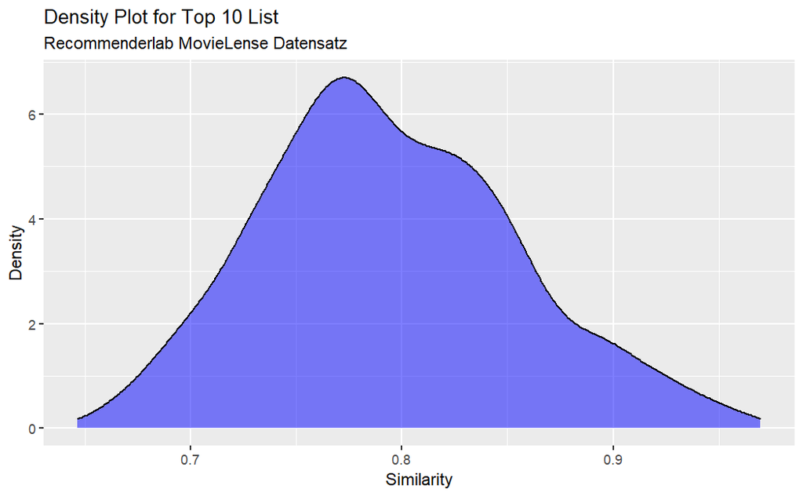

```r
# testing beofre we create a function

top_10_list <- get_topn_recos(movie_rating_matrix, 10)

# create a empty vector
top_10_vec <- c()

# loop through each user
for (user in 1:length(top_10_list)) {
  top_10_vec <- c(top_10_vec, as.numeric(min(top_10_list[[user]])))
}

# create now a density plot with ggplot
ggplot(data.frame(top_10_vec), aes(x = top_10_vec)) +
  geom_density(fill = "blue", alpha = 0.5) +
  labs(title = "Density Plot for Top 10 List",
       x = "Similarity",
       y = "Density",
       subtitle = "Recommenderlab MovieLense Datensatz")
```

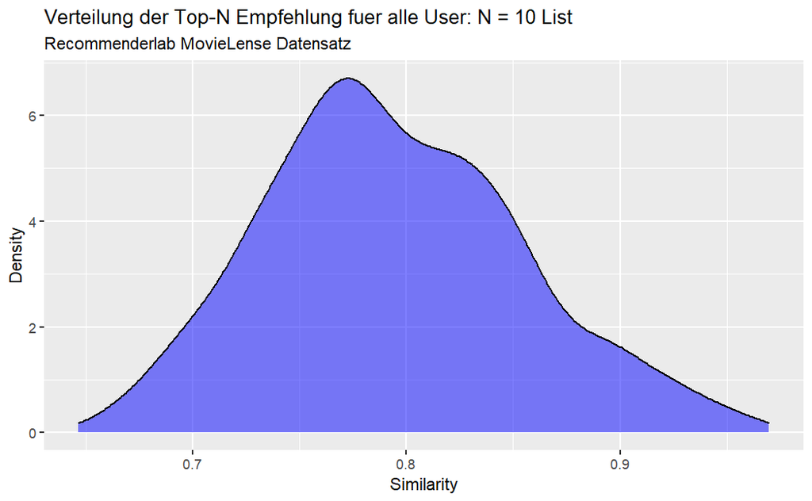

```r
# function for density plot
analyze_topn_recos <- function(rating_matrix, N) {
  top_N_list <- get_topn_recos(rating_matrix, N)
  top_N_vec <- c()

  for (user in 1:length(top_N_list)) {
    top_N_vec <- c(top_N_vec, as.numeric(min(top_N_list[[user]])))
  }

  ggplot(data.frame(top_N_vec), aes(x = top_N_vec)) +
    geom_density(fill = "blue", alpha = 0.5) +
    labs(title = paste("Verteilung der Top-N Empfehlung fuer alle User: N =", N, "List"),
         x = "Similarity",
         y = "Density",
         subtitle = "Recommenderlab MovieLense Datensatz")
}

analyze_topn_recos(movie_rating_matrix, 10)
```

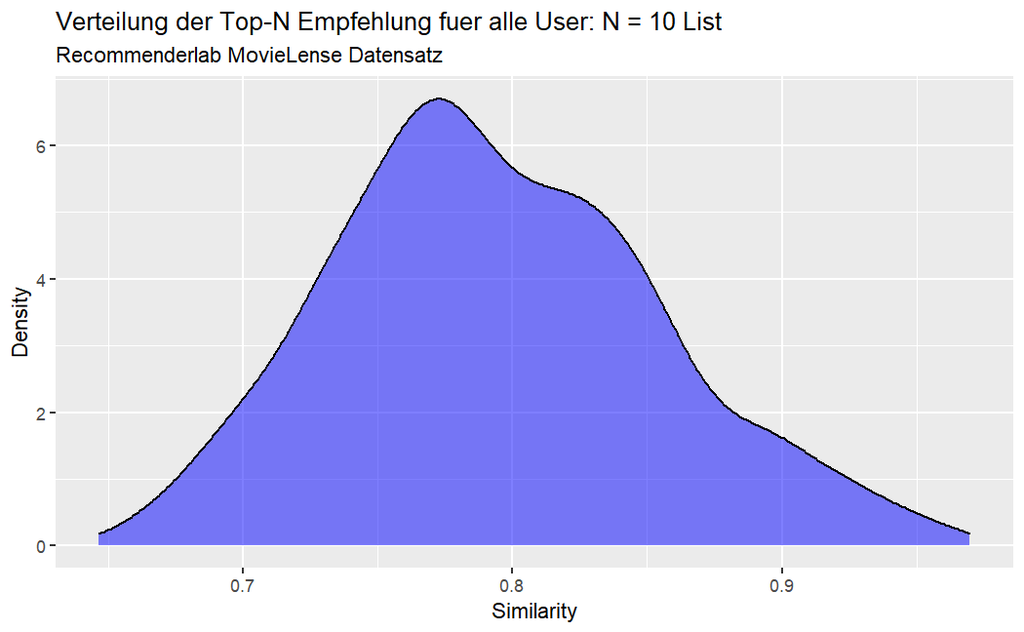

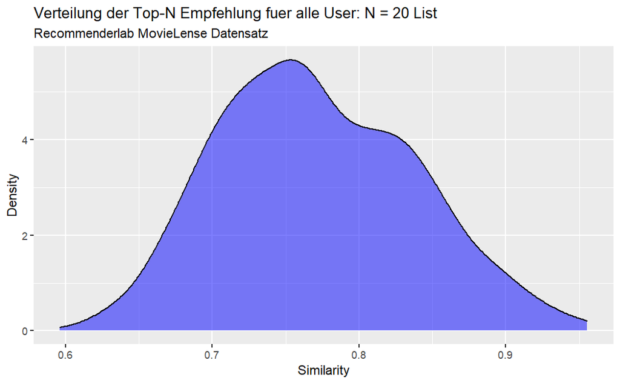

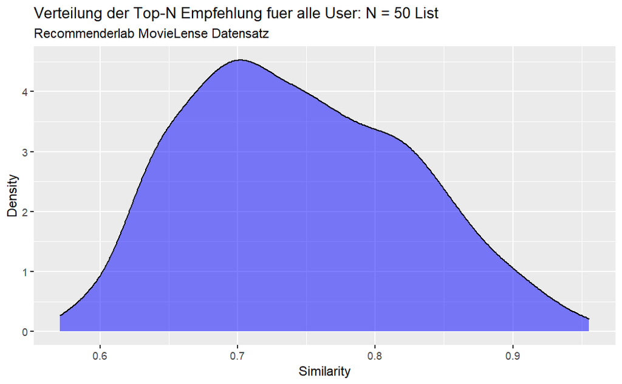

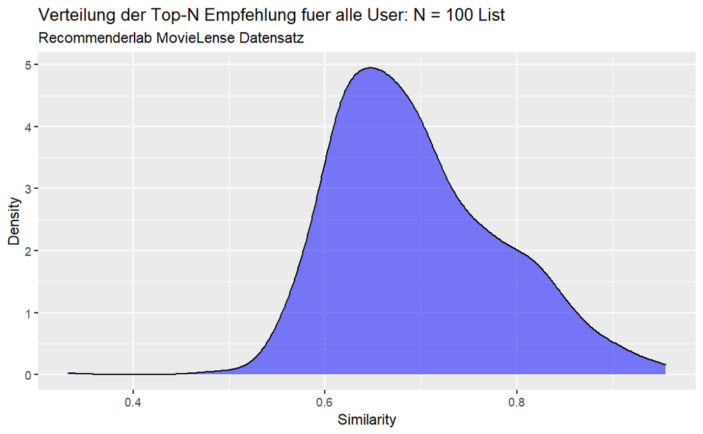

```r
top_N_movies <- c(10,20,50,100)

for (N in top_N_movies) {
  print(analyze_topn_recos(movie_rating_matrix, N))
}
```

Wir können beobachten, dass bei steigenden N, die grösste Merkmalausprägung, sprich die Spitze der Density Verteilung sinkt. Bzw. die Similarity abnimmt. Bei Top N = 10, ist die häufigste Similarity ca. 0.78. Top N = 20, ist diese ca. 0.76, Top N = 50, ist diese ca. 0.7 und bei Top N = 100, ist diese ca. 0.65.

## 4.5 Top-20 Empfehlungen für Nutzer “5”, “25”, “50”, “150” visualisieren.

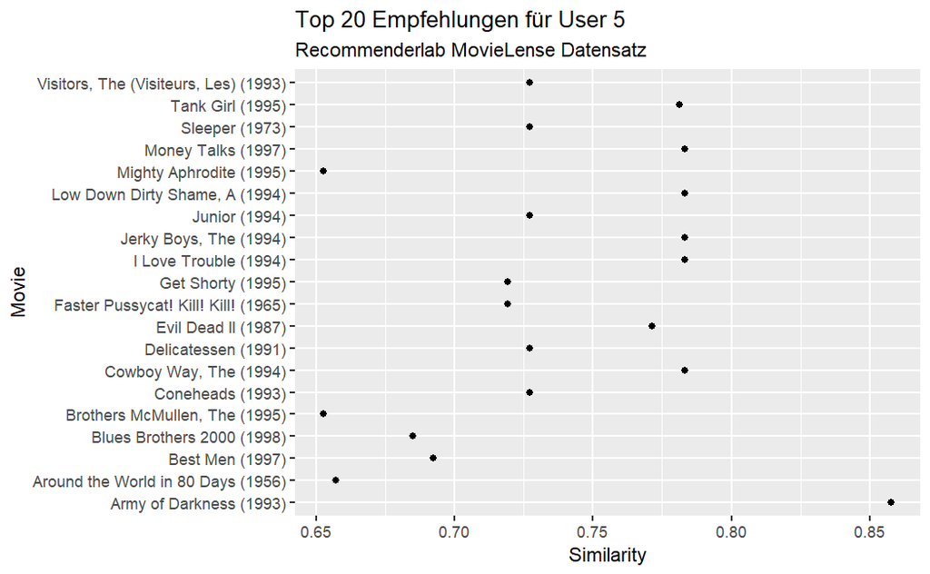

```r
# testing beofre we create a function

top_45_list <- get_topn_recos(movie_rating_matrix, 20)[c(5,25,50,150)]

# top_45_list

movies_45_user5 <- names(top_45_list[[1]])
sim_45_user5 <- as.numeric(top_45_list[[1]])

# create a data frame
df_45_user5 <- data.frame(movies_45_user5, sim_45_user5)

# df_45_user5

# cleveland plot
ggplot(df_45_user5, aes(x = sim_45_user5, y = movies_45_user5)) +
  geom_point() +
  labs(title = "Top 20 Empfehlungen für User 5",
       x = "Similarity",
       y = "Movie",
       subtitle = "Recommenderlab MovieLense Datensatz")
```

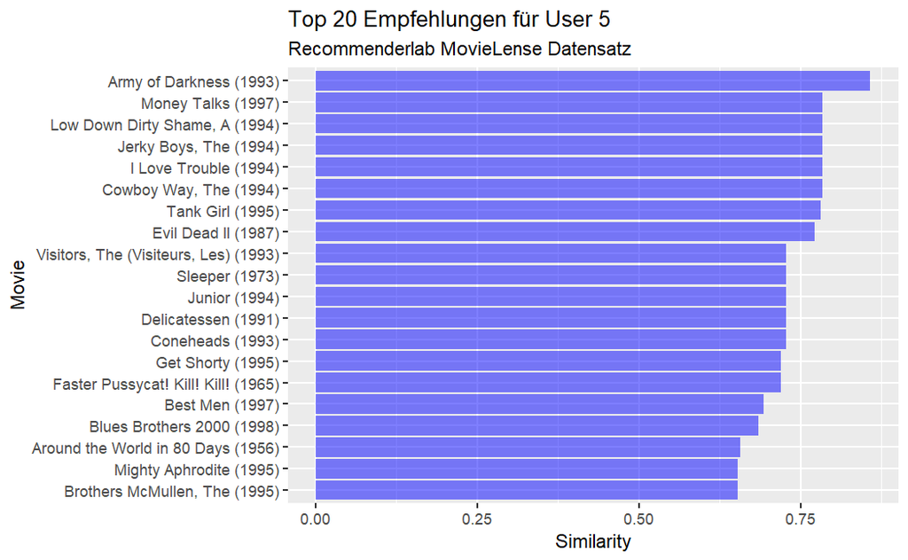

```r
# create a barplot with ggplot and rotate x-axis
ggplot(df_45_user5, aes(x = reorder(movies_45_user5, sim_45_user5), y = sim_45_user5)) +
  geom_bar(stat = "identity", fill = "blue", alpha = 0.5) +
  labs(title = "Top 20 Empfehlungen für User 5",
       x = "Movie",
       y = "Similarity",
       subtitle = "Recommenderlab MovieLense Datensatz") +
  coord_flip()
```

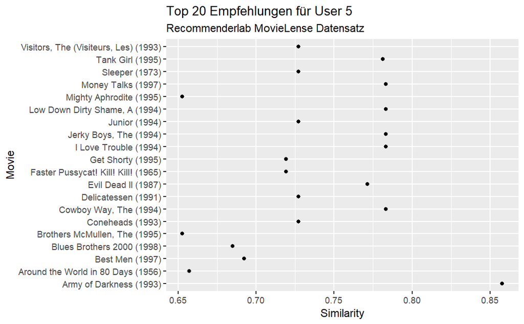

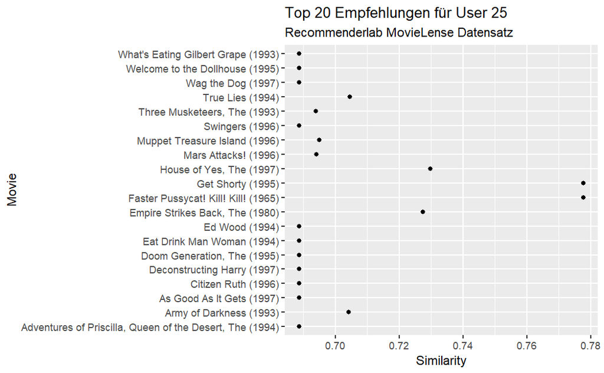

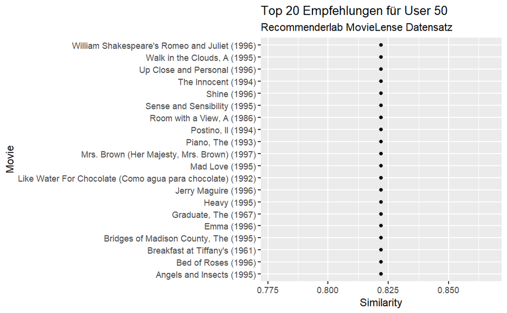

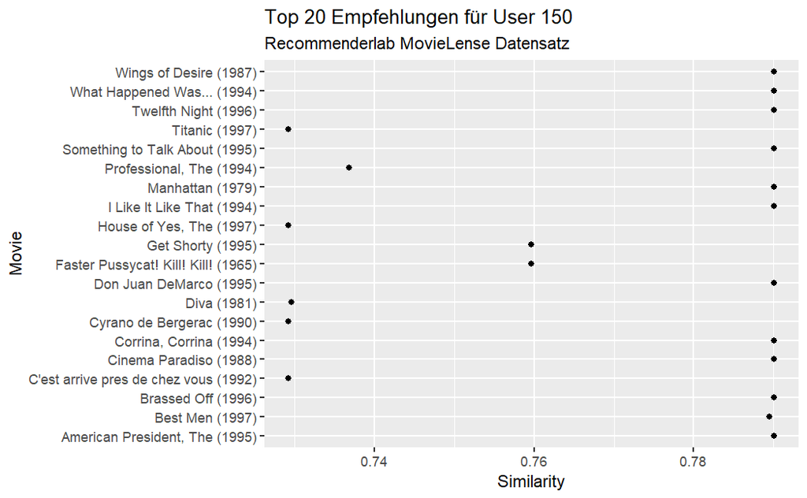

```r
create_cleveland_plot <- function(rating_matrix, N, user) {
  top_N_list <- get_topn_recos(rating_matrix, N)
  top_N_user <- top_N_list[[user]]

  movies_N_user <- names(top_N_user)
  sim_N_user <- as.numeric(top_N_user)

  df_N_user <- data.frame(movies_N_user, sim_N_user)

  # cleveland plot
  ggplot(df_N_user, aes(x = sim_N_user, y = movies_N_user)) +
    geom_point() +
    labs(title = paste("Top", N, "Empfehlungen für User", user),
       x = "Similarity",
       y = "Movie",
       subtitle = "Recommenderlab MovieLense Datensatz")
}

users <- c(5, 25, 50, 150)

for (u in users){
  print(create_cleveland_plot(movie_rating_matrix, 20, u))
}
```

Im clevenad Plot erkennen wir für jeden User die jeweilgen Top 20 Movie Empfehlungen und deren Similarity Wert. Interessant ist User 50, denn diese hat für seine Top 20 Empfehlungen immer den gleichen Similarity Wert. Ein Grund dafür könnte sein, das dieser User sehr wenige Filme bewertet bzw. geschaut hat und dieser User oft ähnliche Filme bewertet hat und unser Recommender Modell somit nur Filme mit dem gleichen Genre vorschlägt die der User angeschaut hat. Bei der Aufgabe 3.2 können wir nachvollziehen, dass dieser User wirklich nur wenige Filme Bewertet hat.

## 4.6 Für Nutzer “133” und “555” Profil mit Top-N Empfehlungen für N = 20, 30, 40, 50 analysieren, visualisieren und diskutieren.

```r
N_list_46 <- c(20,30,40,50)
N_user_46 <- c(133, 555)

rowSums(movielense[N_user_46,])
```

```
 133  555
1638 1612
```

User 133 hat 1638 Filme nicht geschaut bzw bewertet von 1664 vorhandenen Filmen (26 Filme bewertet). User 555 hat 1612 Filme von 1664 nicht geschaut (52 Filme bewertet). User 555 hat somit doppelt so viele Filme bewertet, wie User 133.

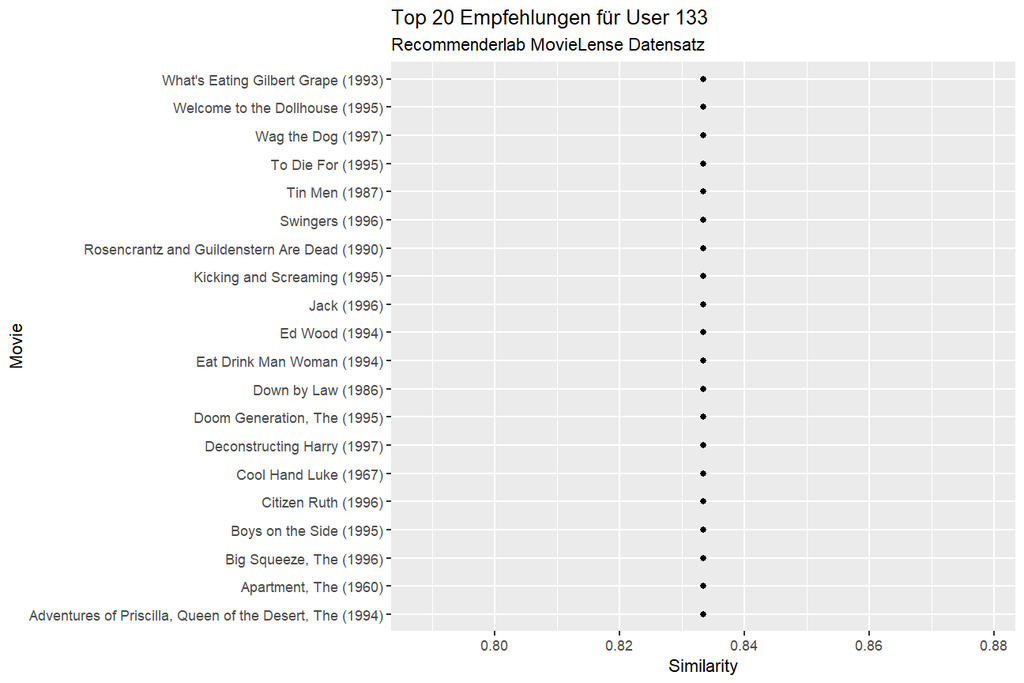

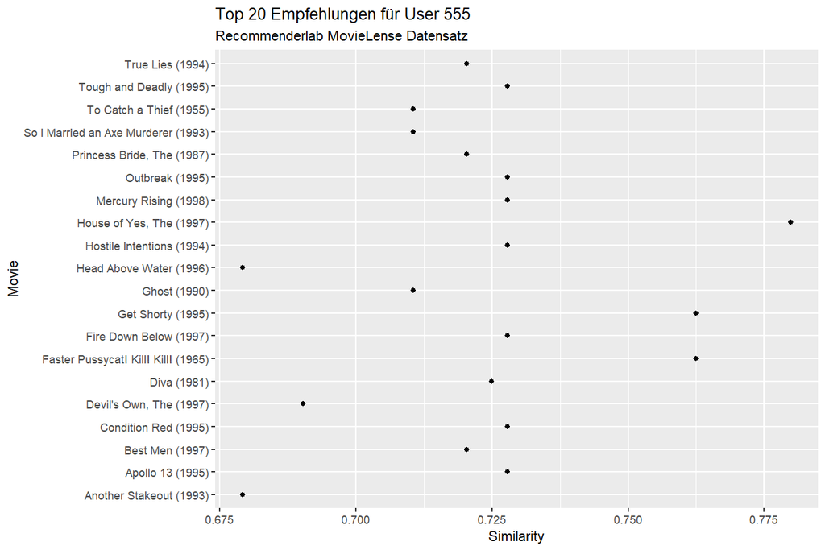

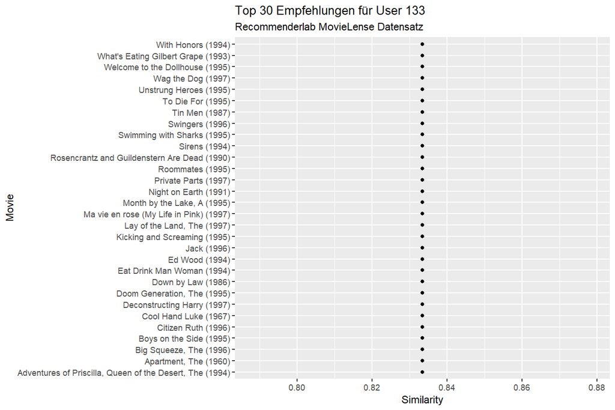

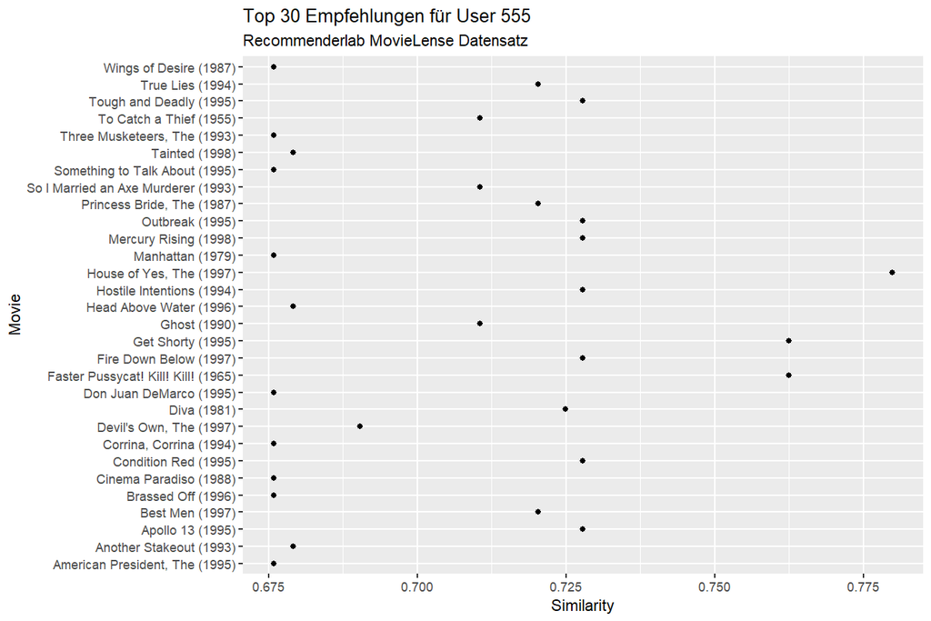

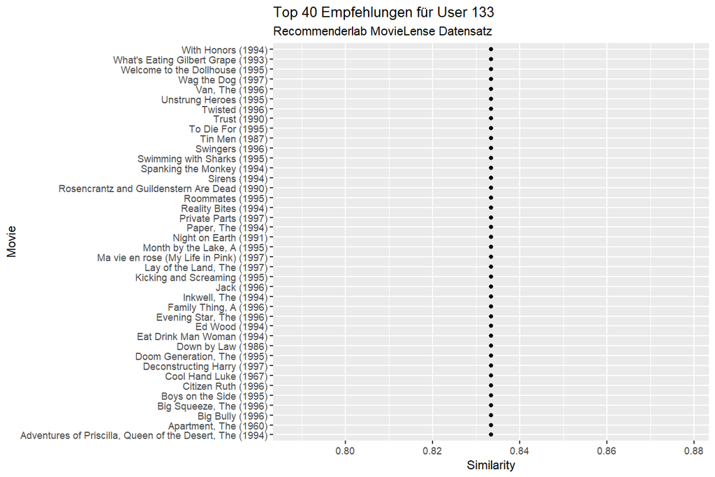

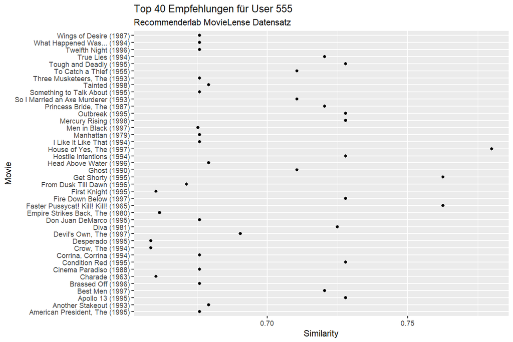

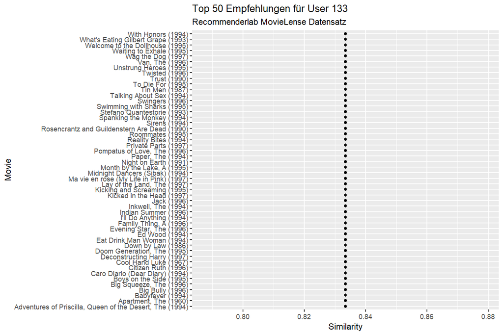

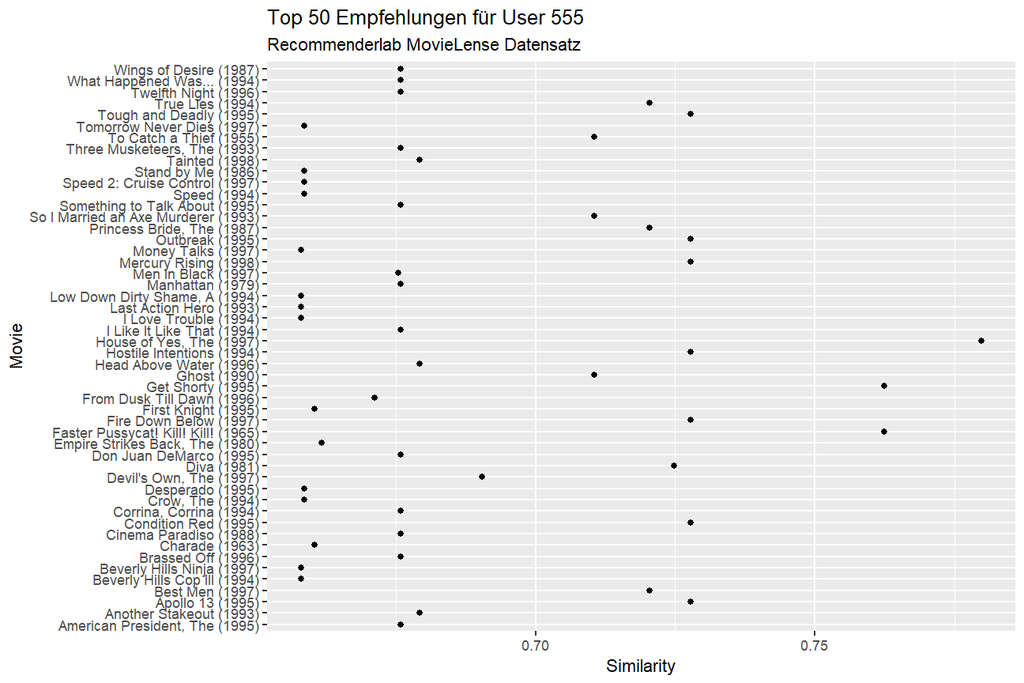

```r
for (N in N_list_46) {
  for (user in N_user_46) {
    print(create_cleveland_plot(movie_rating_matrix, N, user))
  }
}
```

Für den User 133 ist der Recommender sehr eintönig, dies könnte wie bei der vorherigen Aufgabe 4.5 mit User 50 übereinstimmen. Dieser User hat sehr wenige Filme bewertet und meistens nur die vom gleichen Genre. Aus diesem Grund erhält dieser User auch nur Vorschläge von Filmen die dem Genre entsprechen.

Bei User 555 sieht dies anderst aus. Diesem User werden unterschiedliche Filme vorgeschlagen mit unterschiedlichen Similarity Werten.